# ENV 790.30 - Time Series Analysis for Energy Data | Spring 2023

Assignment 7 - Due date 03/20/23

Qiuying Liao

## Directions

You should open the .rmd file corresponding to this assignment on RStudio. The file is available on our class repository on Github. And to do so you will need to fork our repository and link it to your RStudio.

Once you have the file open on your local machine the first thing you will do is rename the file such that it includes your first and last name (e.g., “LuanaLima_TSA_A07_Sp23.Rmd”). Then change “Student Name” on line 4 with your name.

Then you will start working through the assignment by **creating code and output** that answer each question. Be sure to use this assignment document. Your report should contain the answer to each question and any plots/tables you obtained (when applicable).

When you have completed the assignment, **Knit** the text and code into a single PDF file. Submit this pdf using Sakai.

## Set up

```r
#Load/install required package here
library("forecast")
library("tseries")
library("dplyr")
```

```r
library("ggplot2")
library("Kendall")
```

## Importing and processing the data set

Consider the data from the file “Net_generation_United_States_all_sectors_monthly.csv”. The data corresponds to the monthly net generation from January 2001 to December 2020 by source and is provided by the US Energy Information and Administration. **You will work with the natural gas column only**.

Packages needed for this assignment: “forecast”,“tseries”. Do not forget to load them before running your script, since they are NOT default packages.\

### Q1

Import the csv file and create a time series object for natural gas. Make you sure you specify the **start=** and **frequency=** arguments. Plot the time series over time, ACF and PACF.

```r
#import data
energy_df <- read.csv("../Data/Net_generation_United_States_all_sectors_monthly.csv", header=TRUE, skip=4)

#Take out Natural gas
energy_df_NG<-energy_df[,c("Month","natural.gas.thousand.megawatthours")]
head(energy_df_NG)
```

|  | Month | natural.gas.thousand.megawatthours |
| --- | --- | --- |
| 1 | Dec 2020 | 125703.7 |
| 2 | Nov 2020 | 109037.2 |
| 3 | Oct 2020 | 131658.2 |
| 4 | Sep 2020 | 141452.7 |
| 5 | Aug 2020 | 173926.6 |
| 6 | Jul 2020 | 185444.8 |

```r
#rename columns
energy_df_NG <- energy_df_NG %>%
  rename("Month" = 1,"Natural Gas" = 2)
head(energy_df_NG)
```

|  | Month | Natural Gas |
| --- | --- | --- |
| 1 | Dec 2020 | 125703.7 |
| 2 | Nov 2020 | 109037.2 |
| 3 | Oct 2020 | 131658.2 |
| 4 | Sep 2020 | 141452.7 |
| 5 | Aug 2020 | 173926.6 |
| 6 | Jul 2020 | 185444.8 |

```r
#convert month format
Date<-paste(energy_df_NG[,1],"01",sep="")
Date_new<-as.Date(Date,format="%Y %B")
head(Date_new)
```

```
## [1] NA NA NA NA NA NA
```

```r
#time series
ts_energy_df_NG <- ts(energy_df_NG[,2], start = c(2001,1), frequency = 12)
```

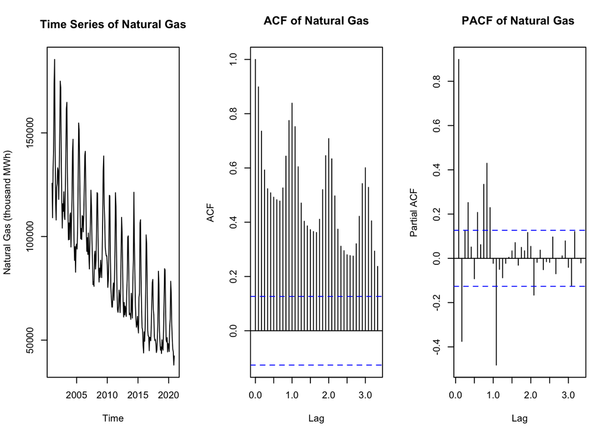

```r
#acf and pacf of the time series
par(mfrow=c(1,3))
plot(ts_energy_df_NG, xlab="Time", ylab="Natural Gas (thousand MWh)", main = "Time Series of Natural Gas")
acf(ts_energy_df_NG, lag=40, main = "ACF of Natural Gas")
pacf(ts_energy_df_NG, lag=40, main = "PACF of Natural Gas ")
```

### Q2

Using the $decompose()$ or $stl()$ and the $seasadj()$ functions create a series without the seasonal component, i.e., a deseasonalized natural gas series. Plot the deseasonalized series over time and corresponding ACF and PACF. Compare with the plots obtained in Q1.

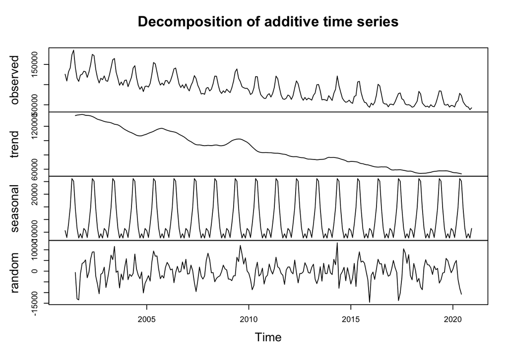

```r
#decompose
decompose_NG <- decompose(ts_energy_df_NG, "additive")
plot(decompose_NG)
```

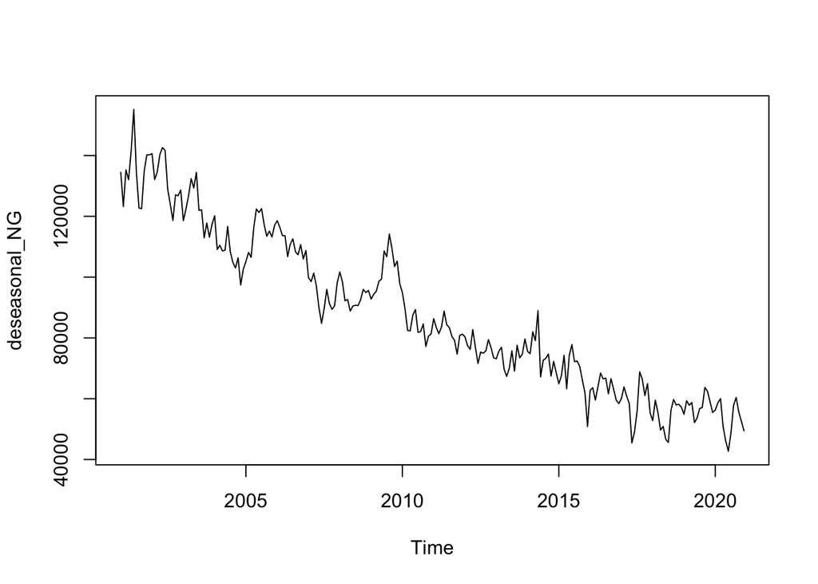

```r
#create non-seasonal natural gas time series
#seasonal adjustment to original data, only works for decompose
deseasonal_NG <- seasadj(decompose_NG)
plot(deseasonal_NG)
```

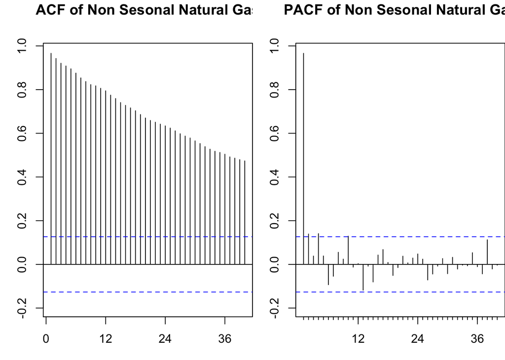

```r
#Comparing ACFs
#seasonality is removed
par(mar=c(3,3,3,0));par(mfrow=c(1,2))
Acf(deseasonal_NG,lag.max=40,main="ACF of Non Sesonal Natural Gas")
Pacf(deseasonal_NG,lag.max=40,main="PACF of Non Sesonal Natural Gas")
```

> Answer: Compared with the plots obtained in Q1, the acf of nonseasonal natural gas have slow decay instead of seasonal spike. Therefore, we removed the seasonality. Also, we removed those little spikes for the seasonality in the pacf of nonseasonal natural gas compared to the pacf of natural gas.

## Modeling the seasonally adjusted or deseasonalized series

### Q3

Run the ADF test and Mann Kendall test on the deseasonalized data from Q2. Report and explain the results.

```r
#Run ADF, check for stationarity
#adf.test(deseasonal_NG,alternative="stationary")
print((adf.test(deseasonal_NG, alternative ="stationary")))
```

```
##
##  Augmented Dickey-Fuller Test
##
## data:  deseasonal_NG
## Dickey-Fuller = -4.0574, Lag order = 6, p-value = 0.01
## alternative hypothesis: stationary
```

```r
#Run Mann Kendall test to check for stationarity
MKtest <- MannKendall(deseasonal_NG)
print("Results for Mann Kendall /n")
```

```
## [1] "Results for Mann Kendall /n"
```

```r
print(summary(MKtest))
```

```
## Score =  -24186 , Var(Score) = 1545533
## denominator =  28680
## tau = -0.843, 2-sided pvalue =< 2.22e-16
## NULL
```

> Answer：The p-value for ADF is 0.01, which is smaller than 0.05 and we can reject the null hypothesis. Therefore, we can say that the stochastic trend is stationary. The p-value for MannKendall test is smaller than 0.05, and we can reject the null hypothesis. Therefore, we can say that there is a deterministic trend. We need to difference it to remove the trend, so d=1.

### Q4

Using the plots from Q2 and test results from Q3 identify the ARIMA model parameters $p,d$ and $q$. Note that in this case because you removed the seasonal component prior to identifying the model you don’t need to worry about seasonal component. Clearly state your criteria and any additional function in R you might use. DO NOT use the $auto.arima()$ function. You will be evaluated on ability to can read the plots and interpret the test results.

```r
# Find out how many time we need to difference
n_diff <- ndiffs(deseasonal_NG)
cat("Number of differencing needed: ",n_diff)
```

```
## Number of differencing needed:  1
```

### Q5

Use $Arima()$ from package “forecast” to fit an ARIMA model to your series considering the order estimated in Q4. You should allow constants in the model, i.e., $include.mean = TRUE$ or $include.drift=TRUE$. **Print the coefficients** in your report. Hint: use the $cat()$ function to print.

```r
#Now let's try ARIMA(2,1,0)
Model_210 <- Arima(deseasonal_NG,order=c(2,1,0),include.drift=TRUE)
print(Model_210)
```

```
## Series: deseasonal_NG
## ARIMA(2,1,0) with drift
##
## Coefficients:
##           ar1      ar2      drift
##       -0.1647  -0.1283  -346.9085
## s.e.   0.0645   0.0650   272.1652
##
## sigma^2 = 29891484:  log likelihood = -2394.61
## AIC=4797.21   AICc=4797.39   BIC=4811.12
```

```r
cat("Coefficient is",Model_210$coef)
```

```
## Coefficient is -0.1647187 -0.1283153 -346.9085
```

### Q6

Now plot the residuals of the ARIMA fit from Q5 along with residuals ACF and PACF on the same window. You may use the $checkresiduals()$ function to automatically generate the three plots. Do the residual series look like a white noise series? Why?

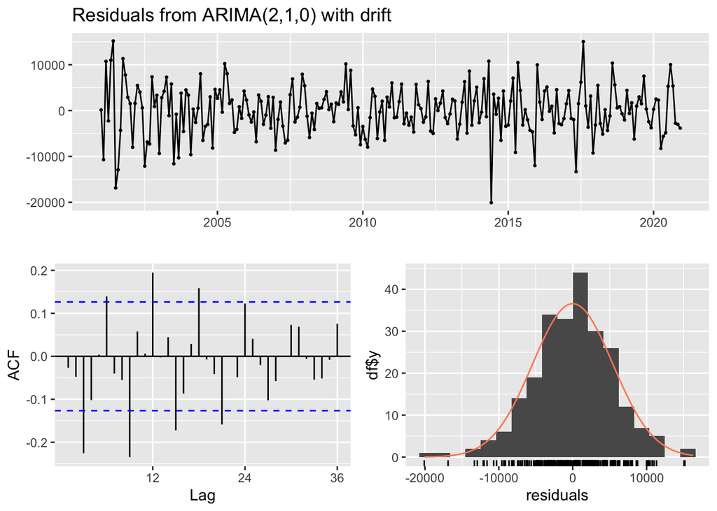

```
##
##  Ljung-Box test
##
## data:  Residuals from ARIMA(2,1,0) with drift
## Q* = 74.829, df = 22, p-value = 1.126e-07
##
## Model df: 2.   Total lags used: 24
```

```r
checkresiduals(Model_210)
```

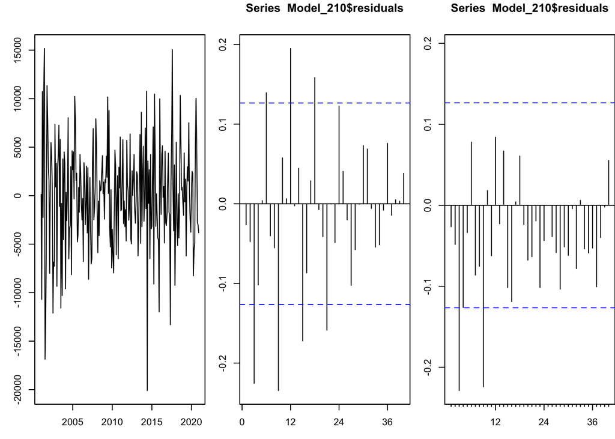

```r
#Check residuals series, if white noise we got a good fit
par(mar=c(3,3,3,0));par(mfrow=c(1,3))
ts.plot(Model_210$residuals)
Acf(Model_210$residuals,lag.max=40)
Pacf(Model_210$residuals,lag.max=40)
```

## Modeling the original series (with seasonality)

### Q7

Repeat Q4-Q6 for the original series (the complete series that has the seasonal component). Note that when you model the seasonal series, you need to specify the seasonal part of the ARIMA model as well, i.e., $P$, $D$ and $Q$.

```r
# Find out how many time we need to difference
ns_diff <- nsdiffs(ts_energy_df_NG)
cat("Number of seasonal differencing needed: ",ns_diff)
```

```
## Number of seasonal differencing needed:  1
```

```r
#Lets difference the series once at lag 12 to remove the seasonal trend.
NG_seas_diff <- diff(ts_energy_df_NG,lag=12, differences=1) #difference at seasonal lag, differncing 1
NG_trend_diff <- diff(ts_energy_df_NG,lag =1, differences=1) #diff done on orig series
NG_both_diff <- diff(NG_trend_diff,lag =12, differences=1)
```

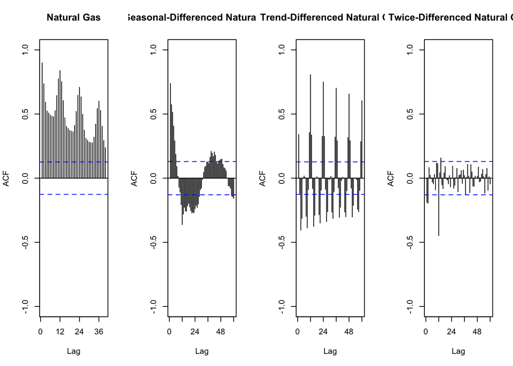

```r
#Check autocorrelation plots for differenced series
#Comparing ACFs
par(mfrow=c(1,4))
Acf(ts_energy_df_NG,lag.max=40,main="Natural Gas",ylim=c(-1,1))
Acf(NG_seas_diff ,lag.max=60,main="Seasonal-Differenced Natural Gas",ylim=c(-1,1)) #at lag 12
Acf(NG_trend_diff,lag.max=60,main="Trend-Differenced Natural Gas",ylim=c(-1,1)) #at lag 1
Acf(NG_both_diff,lag.max=60,main="Twice-Differenced Natural Gas",ylim=c(-1,1))
```

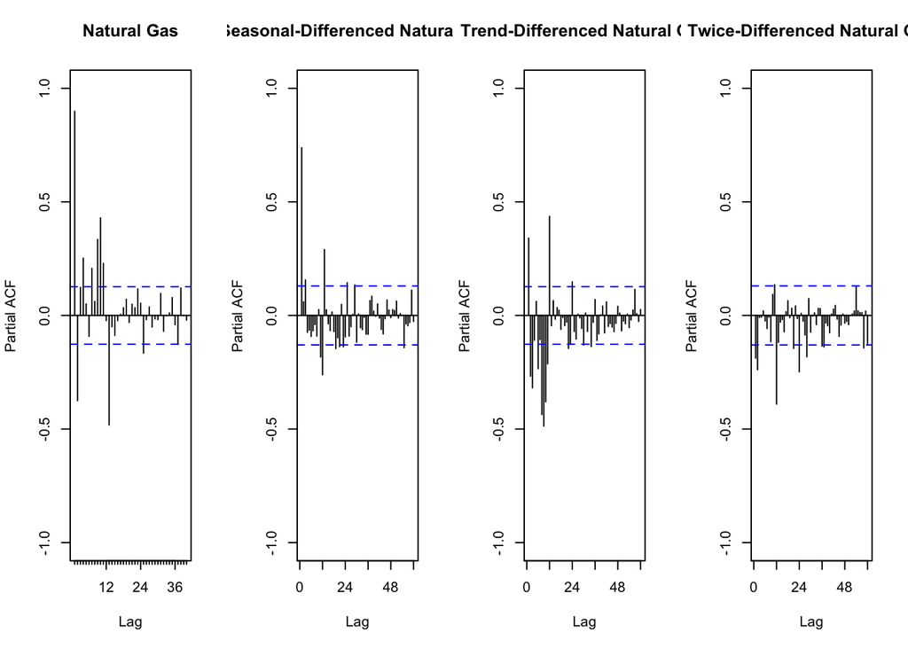

```r
#Comparing PACFs
par(mfrow=c(1,4))
Pacf(ts_energy_df_NG,lag.max=40,main="Natural Gas",ylim=c(-1,1))
Pacf(NG_seas_diff ,lag.max=60,main="Seasonal-Differenced Natural Gas",ylim=c(-1,1)) #at lag 12
Pacf(NG_trend_diff,lag.max=60,main="Trend-Differenced Natural Gas",ylim=c(-1,1)) #at lag 1
Pacf(NG_both_diff,lag.max=60,main="Twice-Differenced Natural Gas",ylim=c(-1,1))
```

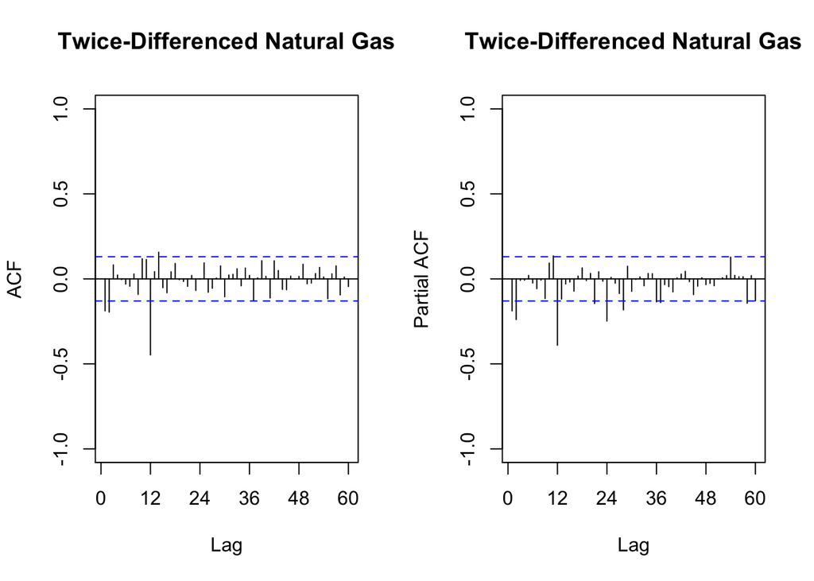

```r
#Plot ACF and PACF for twice-differenced series - Steps 3 (order of non-seasonal) and 5 ) order of seasonal
par(mfrow=c(1,2))
Acf(NG_both_diff,lag.max=60,main="Twice-Differenced Natural Gas",ylim=c(-1,1))
Pacf(NG_both_diff,lag.max=60,main="Twice-Differenced Natural Gas",ylim=c(-1,1))
```

> Answer: We look at the twice differenced series to identify model order. We look at the first 12 lags for ACF and PACF we don’t see slow decays but it looks like we have cut offs at lag 2 on both plots indicating on ARMA (p=2,q=2), and we know from ndiffs that d=1. (p,d,q) = (2,1,2) We look at the seasonal lags only (12,24,36,48). ACF has one spike at 12 and PACF has 2 spikes one at 12 and one at 24. This is an indication of a seasonal moving average (SMA). Therefore, the order of seasonal component is P=0 and Q=1. We know from nsdiffs that D=1. (P,D,Q) = (0,1,1)